# Informe mensual de las cotizaciones al Sistema de la Protección Social

Periodo: diciembre de 2021.

# Resultados principales

- En 2021 el Sistema de la Protección Social siguió registrando afectación en sus indicadores como consecuencia de la pandemia, no obstante, las relaciones laborales tuvieron incrementos periódicos mayores a los observados durante un periodo estándar.

Sólo en noviembre, el número de cotizaciones superaron en 0.1% al número de cotizantes esperados si no hubiera pandemia, llegando a 12.953.581.

# Introducción

## Año tipo 2012 - 2019

### Estimación interanual de las cotizaciones

El IEM está en función del número de cotizantes de cada mes en relación con el número de cotizante en enero de cada año, para ello se toma como referencia una estimación de las cotizaciones en enero 2021 para conocer el total esperado sin afectación por la pandemia y tener un referente de crecimiento.

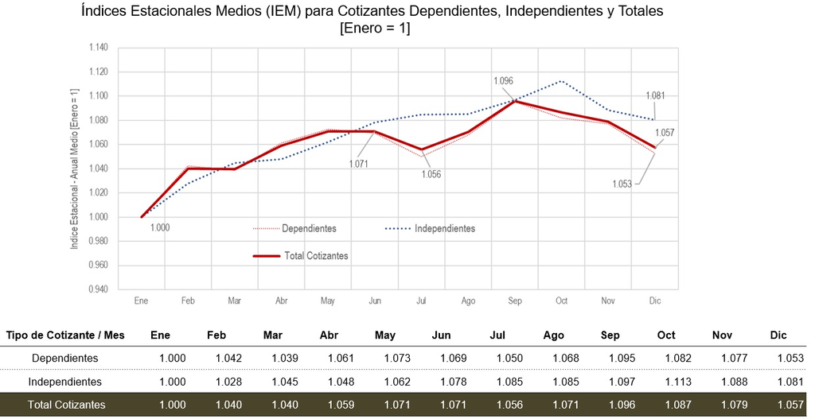

### Estimación de los cotizantes en cada enero para la estimación.

El IEM está en función del número de cotizantes de cada mes en relación con el número de cotizante en enero de cada año, para ello se toma como referencia una estimación de las cotizaciones en enero 2021 para conocer el total esperado sin afectación por la pandemia y tener un referente de crecimiento .

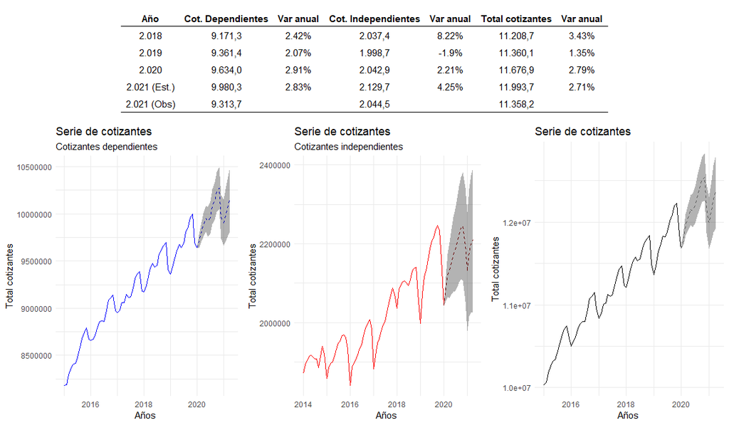

La tabla y el grafico muestra el total de cotizantes estimado para enero 2021 el cual usa un modelo en series de tiempo por cada tipo de cotizante .

# Resumen general de las cotizaciones

Se registraron 12.434.346 relaciones laborales para el periodo de diciembre 2021, superando en 5.98% a las reportadas en diciembre de 2020, incremento que supera al establecido entre 2019 y 2018 para ese mes. Por otro lado, el total las relaciones laborales en diciembre 2021 disminuyen con relación a noviembre en un 4.01% comportamiento usual en este periodo donde se evidencia decrecimientos más fuertes en años pasados.

Total cotizantes en diciembre de cada año.

| Año | Total cotizantes | Total cotizantes Var anual | Total cotizantes Var mensual | Dependientes Total cotizantes | Dependientes Var anual | Dependientes Var mensual | Independientes Total cotizantes | Independientes Var anual | Independientes Var mensual |
| --- | --- | --- | --- | --- | --- | --- | --- | --- | --- |
| 2021 | 12.434,3 | 5,98% | -4,01% | 10.231,2 | 7,17% | -4,11% | 2.203,2 | 0,78% | -3,54% |
| 2020 | 11.732,7 | -2,42% | -2,02% | 9.546,5 | -3,13% | -2,16% | 2.186,1 | 0,82% | -1,39% |
| 2019 | 12.023,7 | 3,96% | -4,49% | 9.855,3 | 3,85% | -4,72% | 2.168,4 | 4,49% | -3,47% |
| 2018 | 11.565,5 | 0,00% | -4,83% | 9.490,4 | 0,00% | -5,11% | 2.075,1 | 0,00% | -3,48% |

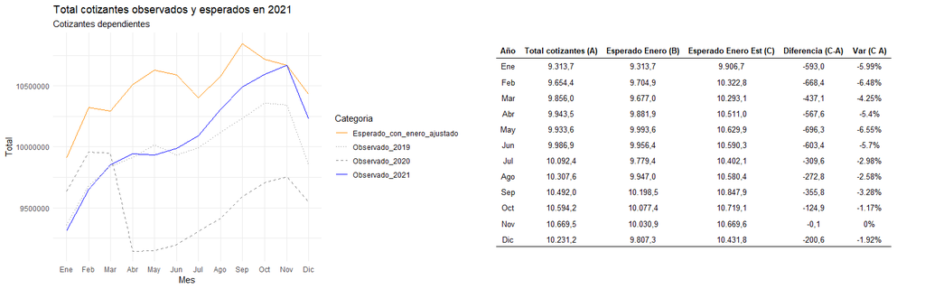

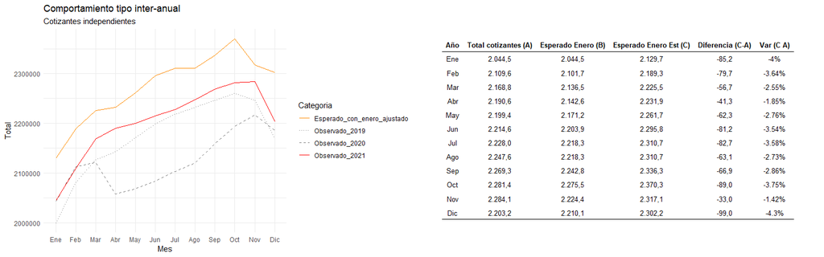

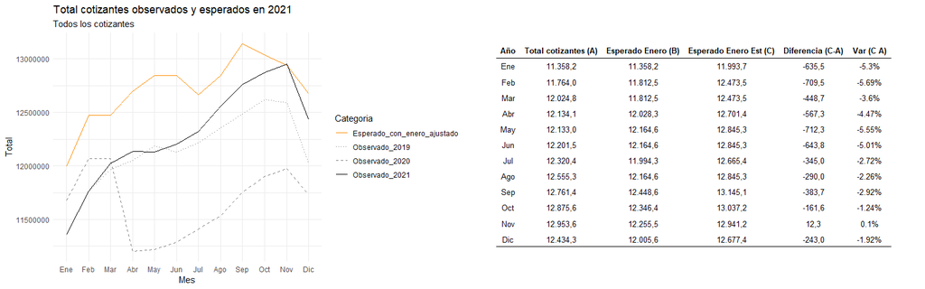

Se observa que solo en noviembre 2021, el número de cotizantes superaron en 0.1% al número de cotizantes esperados si no hubiera pandemia, llegando a 12.953.581 relaciones laborales.

## Distribución por Rango Salarial

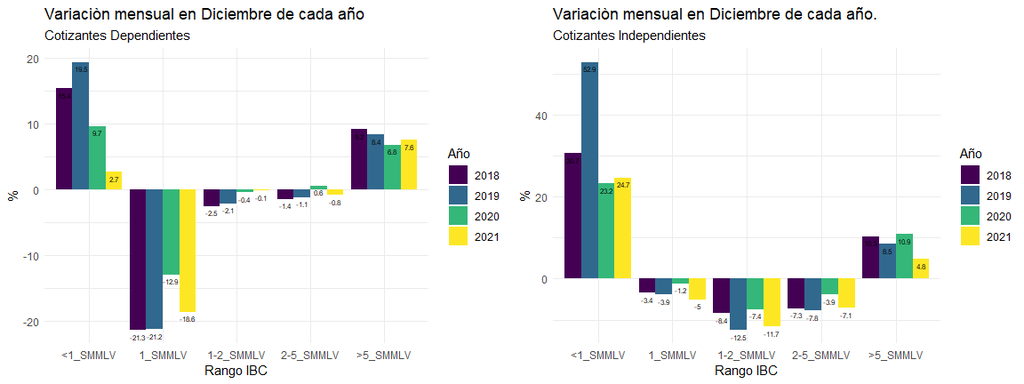

Total, diferencia mensuales y anuales de los cotizantes en diciembre 2021

| Tipo cot. | Rango IBC | Total cot. Diciembre Cot. 2019 | Total cot. Diciembre Cot. 2020 | Total cot. Diciembre Cot. 2021 | Diferencia mes 2018 | Diferencia mes 2019 | Diferencia mes 2020 | Diferencia mes 2021 | Diferencia anual 2019 | Diferencia anual 2020 | Diferencia anual 2021 |
| --- | --- | --- | --- | --- | --- | --- | --- | --- | --- | --- | --- |
| Dependientes | <1_SMMLV | 1.047,8 | 900,3 | 984,7 | 131,3 | 170,6 | 79,7 | 25,9 | 66,4 | -147,5 | 84,4 |
| Dependientes | 1_SMMLV | 2.356,0 | 2.356,9 | 2.459,4 | -607,9 | -635,4 | -349,8 | -560,5 | 112,7 | 0,9 | 102,5 |
| Dependientes | 1-2_SMMLV | 3.659,1 | 3.563,2 | 3.770,2 | -91,3 | -78,3 | -12,8 | -5,3 | 121,0 | -95,9 | 207,0 |
| Dependientes | 2-5_SMMLV | 1.815,3 | 1.774,2 | 1.927,9 | -24,6 | -20,6 | 11,4 | -15,6 | 46,4 | -41,0 | 153,6 |
| Dependientes | >5_SMMLV | 977,2 | 951,9 | 1.021,8 | 81,0 | 75,9 | 60,7 | 71,8 | 18,4 | -25,2 | 69,9 |
| Dependientes | Total | 10.164,0 | 9.546,5 | 10.164,0 | -511,5 | -487,7 | -210,8 | -483,7 | 364,9 | -308,8 | 617,4 |
| Independientes | <1_SMMLV | 131,5 | 114,5 | 130,8 | 18,3 | 45,5 | 21,6 | 25,9 | 53,4 | -17,0 | 16,3 |
| Independientes | 1_SMMLV | 1.401,1 | 1.411,5 | 1.351,8 | -47,8 | -56,4 | -17,0 | -71,5 | 36,9 | 10,4 | -59,7 |
| Independientes | 1-2_SMMLV | 389,2 | 413,9 | 420,1 | -36,6 | -55,5 | -33,3 | -55,5 | -10,3 | 24,7 | 6,2 |
| Independientes | 2-5_SMMLV | 189,5 | 190,4 | 195,6 | -14,0 | -16,0 | -7,7 | -15,0 | 11,1 | 0,9 | 5,1 |
| Independientes | >5_SMMLV | 57,1 | 55,8 | 59,2 | 5,1 | 4,5 | 5,5 | 2,7 | 2,2 | -1,3 | 3,4 |
| Independientes | Total | 2.157,4 | 2.186,1 | 2.157,4 | -74,9 | -77,9 | -30,9 | -113,4 | 93,3 | 17,8 | -28,8 |
| Total | <1_SMMLV | 1.179,3 | 1.014,8 | 1.115,5 | 149,7 | 216,1 | 101,3 | 51,8 | 119,8 | -164,5 | 100,7 |
| Total | 1_SMMLV | 3.757,1 | 3.768,4 | 3.811,1 | -655,7 | -691,8 | -366,7 | -632,0 | 149,6 | 11,3 | 42,7 |
| Total | 1-2_SMMLV | 4.048,3 | 3.977,2 | 4.190,3 | -127,9 | -133,9 | -46,1 | -60,9 | 110,7 | -71,2 | 213,2 |
| Total | 2-5_SMMLV | 2.004,8 | 1.964,6 | 2.123,4 | -38,5 | -36,6 | 3,7 | -30,5 | 57,5 | -40,1 | 158,8 |
| Total | >5_SMMLV | 1.034,2 | 1.007,7 | 1.081,0 | 86,1 | 80,4 | 66,2 | 74,6 | 20,6 | -26,5 | 73,3 |
| Total | Total | 12.321,3 | 11.732,7 | 12.321,3 | -586,4 | -565,7 | -241,6 | -597,1 | 458,2 | -291,0 | 588,6 |

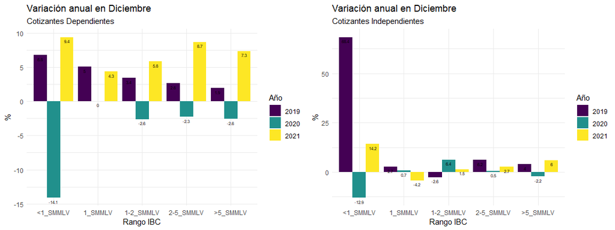

## Comportamiento de las novedades

### Dependientes

El total de relaciones laborales con novedad de ingreso, retiro, suspensión temporal y vacaciones en diciembre 2021 fue de 704.031, 1.414.454, 276.823 y 1.438.952 respectivamente, es decir que tuvieron variaciones mensuales de -20.02%, 34.91%, 11.08% y 276.37%.

El porcentaje de vacaciones en diciembre 2021 fue del 14,1%, mientras que en 2019 era del 17,1%. Es notorio los incremento en esta novedad para los periodos de mayor afectación por la pandemia, así como las suspensiones temporales. La siguiente grafica muestra el porcentaje de relaciones laborales de cada novedad para cada periodo de aporte en los últimos tres años.

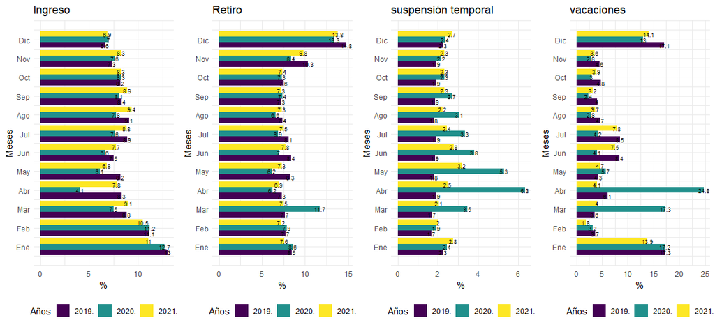

Variaciones anuales de novedades de ingreso, retiro, suspension temporales y vacaciones

| Mes | Ingresos 2019 | Ingresos 2020 | Ingresos 2021 | Retiros 2019 | Retiros 2020 | Retiros 2021 | Suspensiones temporales 2019 | Suspensiones temporales 2020 | Suspensiones temporales 2021 | Vacaciones 2019 | Vacaciones 2020 | Vacaciones 2021 |
| --- | --- | --- | --- | --- | --- | --- | --- | --- | --- | --- | --- | --- |
| Ene | 1,0% | 0,5% | -16,0% | -1,8% | 4,0% | -14,3% | 6,3% | 10,7% | 9,5% | 6,4% | 2,5% | -22,1% |
| Feb | -1,2% | 3,4% | -9,1% | -0,3% | 4,7% | -11,1% | 4,8% | 17,6% | 2,6% | 10,1% | -9,8% | -45,3% |
| Mar | 0,7% | -14,5% | 20,0% | 3,8% | 54,4% | -36,6% | 4,5% | 102,5% | -40,9% | -27,8% | 383,3% | -77,2% |
| Abr | -2,2% | -55,0% | 109,4% | 0,4% | -21,7% | 21,2% | 15,1% | 205,3% | -57,2% | 31,9% | 274,3% | -82,0% |
| May | 2,3% | -32,3% | 21,3% | 2,4% | -32,1% | 28,2% | 11,7% | 168,6% | -34,7% | 21,8% | 22,6% | -11,6% |
| Jun | 0,9% | -19,0% | 27,4% | -5,0% | -23,2% | 20,5% | 11,2% | 90,1% | -20,7% | 9,7% | -55,1% | 100,4% |
| Jul | 9,1% | -20,4% | 25,6% | 4,5% | -20,8% | 17,9% | 13,2% | 60,7% | -20,9% | -6,6% | -53,8% | 101,6% |
| Ago | -4,8% | -20,8% | 32,3% | -1,7% | -17,0% | 22,1% | 9,8% | 58,7% | -20,1% | 4,8% | -44,5% | 44,2% |
| Sep | 5,9% | -9,2% | 20,4% | 4,0% | -5,1% | 7,8% | 13,1% | 35,6% | -6,0% | 14,2% | -44,7% | 47,6% |
| Oct | 4,5% | -5,8% | 9,5% | 4,2% | -9,6% | 10,7% | 10,7% | 14,7% | 8,8% | 13,0% | -41,9% | 43,1% |
| Nov | -0,7% | -2,0% | 18,2% | -1,2% | -23,2% | 27,6% | 14,3% | 5,4% | 18,2% | 17,1% | -41,4% | 37,8% |
| Dic | 1,3% | 1,9% | 5,6% | 8,7% | -12,7% | 11,0% | 13,7% | 1,3% | 22,4% | 10,5% | -26,5% | 16,1% |

Variaciones mensuales de novedades de ingreso, retiro, suspension temporales y vacaciones

| Mes | Ingresos 2019 | Ingresos 2020 | Ingresos 2021 | Retiros 2019 | Retiros 2020 | Retiros 2021 | Suspensiones temporales 2019 | Suspensiones temporales 2020 | Suspensiones temporales 2021 | Vacaciones 2019 | Vacaciones 2020 | Vacaciones 2021 |
| --- | --- | --- | --- | --- | --- | --- | --- | --- | --- | --- | --- | --- |
| Ene | 88,7% | 87,2% | 54,3% | -40,7% | -43,3% | -44,3% | 8,2% | 5,3% | 13,8% | 6,0% | -1,7% | 4,3% |
| Feb | -11,6% | -9,0% | -1,6% | -6,0% | -5,3% | -1,8% | -23,5% | -18,7% | -23,8% | -77,8% | -80,5% | -86,3% |
| Mar | -19,2% | -33,2% | -11,9% | 1,0% | 48,9% | 6,1% | 4,5% | 80,0% | 3,7% | -0,7% | 431,8% | 121,9% |
| Abr | -5,2% | -50,1% | -13,0% | -4,0% | -51,3% | -6,8% | 11,8% | 68,5% | 22,0% | 70,2% | 31,9% | 3,9% |
| May | -0,1% | 50,3% | -12,9% | 14,9% | -0,5% | 5,3% | -4,9% | -16,4% | 27,6% | -29,4% | -76,9% | 13,7% |
| Jun | -9,1% | 8,8% | 14,2% | 0,5% | 13,6% | 6,8% | 2,1% | -27,7% | -12,3% | 94,4% | -28,8% | 61,6% |
| Jul | 19,1% | 17,1% | 15,3% | -3,3% | -0,1% | -2,3% | 5,2% | -11,1% | -11,3% | 2,3% | 5,1% | 5,7% |
| Ago | 3,4% | 2,9% | 8,4% | -8,0% | -3,7% | -0,2% | -6,0% | -7,2% | -6,2% | -44,6% | -33,4% | -52,4% |
| Sep | -7,2% | 6,4% | -3,1% | -0,0% | 14,3% | 0,9% | 4,5% | -10,7% | 5,1% | -12,9% | -13,4% | -11,3% |
| Oct | -0,4% | 3,2% | -6,1% | 5,1% | 0,1% | 2,7% | 4,1% | -11,9% | 1,9% | 20,9% | 27,0% | 23,1% |
| Nov | -10,8% | -7,2% | 0,2% | 36,8% | 16,3% | 34,0% | 0,9% | -7,3% | 0,7% | -4,5% | -3,6% | -7,2% |
| Dic | -13,9% | -10,5% | -20,0% | 36,3% | 55,0% | 34,9% | 11,6% | 7,3% | 11,1% | 256,0% | 346,6% | 276,4% |

#### Detalle en las novedades de ingresos

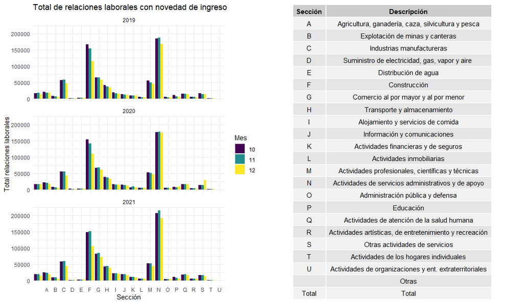

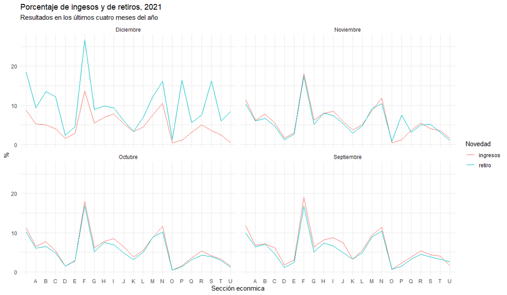

### Independientes

El total de relaciones laborales con novedades de ingreso y retiro en los cotizantes independientes fue de 129.672 y 277.076 respectivamente, con variaciones mensuales de -11,7% y 98,7%.

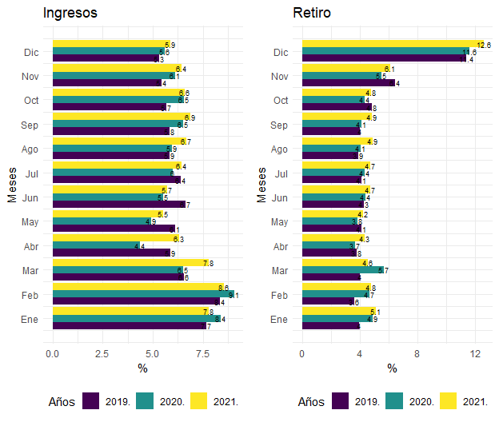

Variaciones anuales de novedades de ingreso y retiro

| Mes | Ingresos 2019 | Ingresos 2020 | Ingresos 2021 | Retiros 2019 | Retiros 2020 | Retiros 2021 |
| --- | --- | --- | --- | --- | --- | --- |
| Ene | -11,3% | 11,8% | -7,2% | 27,7% | 27,2% | 3,7% |
| Feb | 32,1% | 10,0% | -5,7% | 45,5% | 29,6% | 2,2% |
| Mar | 47,7% | -0,9% | 22,1% | 60,0% | 41,2% | -17,1% |
| Abr | 36,7% | -28,9% | 54,8% | 41,3% | -6,5% | 24,7% |
| May | 47,3% | -23,6% | 19,7% | 50,8% | -11,1% | 16,6% |
| Jun | 55,8% | -21,6% | 10,8% | 24,6% | -3,4% | 15,0% |
| Jul | 22,0% | -11,2% | 13,5% | 14,3% | -0,2% | 15,3% |
| Ago | -3,0% | -3,7% | 19,5% | 23,4% | -1,1% | 27,8% |
| Sep | -0,8% | 7,1% | 11,1% | 8,8% | -0,8% | 23,4% |
| Oct | 2,4% | 12,1% | 5,1% | 41,6% | -12,4% | 14,1% |
| Nov | 8,5% | 11,1% | 8,5% | 27,7% | -15,9% | 14,9% |
| Dic | 11,3% | 6,0% | 6,3% | 47,8% | 3,0% | 9,2% |

Variaciones anuales de novedades de ingreso, retiro, suspension temporales y vacaciones

| Mes | Ingresos 2019 | Ingresos 2020 | Ingresos 2021 | Retiros 2019 | Retiros 2020 | Retiros 2021 |
| --- | --- | --- | --- | --- | --- | --- |
| Ene | 48,2% | 49,0% | 30,4% | -52,6% | -59,2% | -59,0% |
| Feb | 13,5% | 11,6% | 13,5% | -3,9% | -2,1% | -3,5% |
| Mar | -19,7% | -27,6% | -6,3% | 11,9% | 21,9% | -1,1% |
| Abr | -9,8% | -35,3% | -17,9% | -4,3% | -36,6% | -4,6% |
| May | 5,6% | 13,4% | -12,4% | 10,1% | 4,6% | -2,1% |
| Jun | 9,9% | 12,8% | 4,5% | 5,3% | 14,4% | 12,8% |
| Jul | -2,9% | 10,0% | 12,7% | -2,6% | 0,7% | 0,9% |
| Ago | -8,0% | -0,2% | 5,1% | -5,5% | -6,3% | 3,9% |
| Sep | 0,5% | 11,7% | 3,9% | 3,9% | 4,1% | 0,5% |
| Oct | -2,5% | 2,0% | -3,5% | 20,9% | 6,8% | -1,2% |
| Nov | -4,9% | -5,7% | -2,6% | 32,4% | 27,0% | 27,9% |
| Dic | -5,5% | -9,9% | -11,7% | 70,7% | 109,1% | 98,7% |

# Seguimiento longitudinal

## Cotizantes dependentes del sector privado

En diciembre 2021 se identificaron 8.737.634 cotizantes dependientes de aportantes del sector privado, con una variación mensual de -1.7% inferior a la obtenida en 2020 que fue del -0.4%, pero superior a la variación en 2019 que cayó -1.8%.

Matriz resumen de la dinamica pareada entre Diciembre y Noviembre de 2021

| Mes | Entran | Permanecen | Salen | Salen con Retiro | Salen sin Retiro | Entran (%) | Salen (%) |
| --- | --- | --- | --- | --- | --- | --- | --- |
| <=1SMMLV | 466.437 | 2.510.233 | 564.629 | 506.624 | 58.005 | 15.67% | 18.36% |
| 1-2_SMMLV | 103.985 | 3.518.510 | 144.505 | 120.357 | 24.148 | 2.87% | 3.94% |
| 2-3_SMMLV | 14.441 | 846.607 | 34.074 | 30.869 | 3.205 | 1.68% | 3.87% |
| 3-4_SMMLV | 5.522 | 403.105 | 12.963 | 11.699 | 1.264 | 1.35% | 3.12% |
| 4-5_SMMLV | 2.771 | 223.911 | 6.568 | 5.922 | 646 | 1.22% | 2.85% |
| >5_SMMLV | 5.048 | 604.498 | 13.313 | 12.031 | 1.282 | 0.83% | 2.15% |
| Total | 598.204 | 8.106.864 | 776.052 | 687.502 | 88.550 | 6.87% | 8.74% |

Matriz resumen de la dinamica pareada entre Noviembre y Octubre de 2021

| Mes | Entran | Permanecen | Salen | Salen con Retiro | Salen sin Retiro | Entran (%) | Salen (%) |
| --- | --- | --- | --- | --- | --- | --- | --- |
| <=1SMMLV | 603.779 | 2.606.625 | 503.082 | 467.203 | 35.879 | 18.81% | 16.18% |
| 1-2_SMMLV | 93.437 | 3.520.924 | 106.911 | 95.385 | 11.526 | 2.59% | 2.95% |
| 2-3_SMMLV | 16.116 | 846.606 | 22.404 | 21.093 | 1.311 | 1.87% | 2.58% |
| 3-4_SMMLV | 6.402 | 405.542 | 9.053 | 8.476 | 577 | 1.55% | 2.18% |
| 4-5_SMMLV | 3.363 | 222.767 | 4.857 | 4.575 | 282 | 1.49% | 2.13% |
| >5_SMMLV | 5.596 | 538.108 | 12.379 | 11.843 | 536 | 1.03% | 2.25% |
| Total | 728.693 | 8.140.572 | 658.686 | 608.575 | 50.111 | 8.22% | 7.49% |

- La diferencia de salidas en 2021 con salidas en 2020 es de 159.722 esta cifra es superior a la diferencia de las salidas entre 2020 y 2019, periodo en el que se registraron -92.602. El número de salidas en diciembre 2019 y diciembre 2020 fueron de 708.932 y 616.330 respectivamente.
- La diferencia de entradas en 2021 con entradas en 2020 es de 22.940 , este dato es inferior a la diferencia de las entradas entre 2020 y 2019, que llegó a 23.844. El número de entradas en diciembre 2019 y 2020 fueron de 551.420 y 575.264 respectivamente.

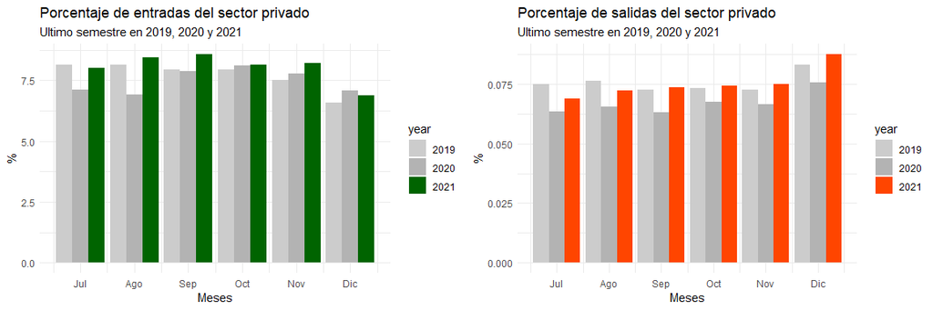

Matriz resumen de la dinamica pareada entre Diciembre y Noviembre de 2020

| Mes | Entran | Permanecen | Salen | Salen con Retiro | Salen sin Retiro | Entran (%) | Salen (%) |
| --- | --- | --- | --- | --- | --- | --- | --- |
| <=1SMMLV | 460.818 | 2.350.465 | 463.862 | 443.544 | 20.318 | 16.39% | 16.48% |
| 1-2_SMMLV | 91.864 | 3.322.645 | 105.285 | 98.880 | 6.405 | 2.69% | 3.07% |
| 2-3_SMMLV | 11.618 | 773.139 | 24.298 | 23.664 | 634 | 1.48% | 3.05% |
| 3-4_SMMLV | 4.666 | 355.769 | 8.904 | 8.634 | 270 | 1.29% | 2.44% |
| 4-5_SMMLV | 2.259 | 193.515 | 4.475 | 4.347 | 128 | 1.15% | 2.26% |
| >5_SMMLV | 4.039 | 549.362 | 9.506 | 9.191 | 315 | 0.73% | 1.7% |
| Total | 575.264 | 7.544.895 | 616.330 | 588.260 | 28.070 | 7.08% | 7.55% |

Matriz resumen de la dinamica pareada entre Diciembre y Noviembre de 2019

| Mes | Entran | Permanecen | Salen | Salen con Retiro | Salen sin Retiro | Entran (%) | Salen (%) |
| --- | --- | --- | --- | --- | --- | --- | --- |
| <=1SMMLV | 443.317 | 2.447.461 | 520.396 | 496.727 | 23.669 | 15.34% | 17.53% |
| 1-2_SMMLV | 85.621 | 3.427.877 | 129.391 | 121.589 | 7.802 | 2.44% | 3.64% |
| 2-3_SMMLV | 11.599 | 780.328 | 30.435 | 29.538 | 897 | 1.46% | 3.75% |
| 3-4_SMMLV | 4.641 | 380.320 | 11.514 | 11.067 | 447 | 1.21% | 2.94% |
| 4-5_SMMLV | 2.318 | 208.713 | 5.554 | 5.345 | 209 | 1.1% | 2.59% |
| >5_SMMLV | 3.924 | 574.148 | 11.642 | 11.059 | 583 | 0.68% | 1.99% |
| Total | 551.420 | 7.818.847 | 708.932 | 675.325 | 33.607 | 6.59% | 8.31% |

**Relaciones laborales que permanecieron**

El porcentaje promedio de las relaciones laborales que disminuyeron, aumentaron o permanecieron en su rango salarial fue de 12.45%,16.55% y 75.83%, similares a los promedios observados en 2020 cuando se ubicaron en 11.87%,16.64% y 76.24% respectivamente, y al promedio 2019 que fueron del 12.8%,17.03% y 75.14%.

Matriz de trancisión entre Noviembre y Diciembre de 2021

| Rango pre | <=1SMMLV | 1-2SMMLV | 2-3SMMLV | 3-4SMMLV | 4-5SMMLV | >5SMMLV | Disminuyen % | Incrementan % |
| --- | --- | --- | --- | --- | --- | --- | --- | --- |
| <=1SMMLV | 84.39% | 14.82% | 0.58% | 0.13% | 0.04% | 0.04% | 0% | 15.61% |
| 1-2SMMLV | 7.3% | 86.55% | 5.23% | 0.62% | 0.16% | 0.13% | 7.3% | 6.15% |
| 2-3SMMLV | 1.51% | 12.74% | 70.78% | 10.25% | 2.46% | 2.26% | 14.25% | 14.97% |
| 3-4SMMLV | 0.62% | 2.26% | 12.49% | 63.78% | 10.81% | 10.05% | 15.37% | 20.86% |
| 4-5SMMLV | 0.39% | 0.99% | 3.71% | 11.57% | 58.15% | 25.18% | 16.66% | 25.18% |
| >5SMMLV | 0.16% | 0.32% | 0.85% | 2.48% | 4.89% | 91.31% | 8.69% | 0% |

Matriz de trancisión entre Noviembre y Diciembre de 2020

| Rango pre | <=1SMMLV | 1-2SMMLV | 2-3SMMLV | 3-4SMMLV | 4-5SMMLV | >5SMMLV | Disminuyen % | Incrementan % |
| --- | --- | --- | --- | --- | --- | --- | --- | --- |
| <=1SMMLV | 85.81% | 13.49% | 0.52% | 0.11% | 0.03% | 0.04% | 0% | 14.19% |
| 1-2SMMLV | 6.87% | 87.15% | 5.1% | 0.59% | 0.16% | 0.13% | 6.87% | 5.98% |
| 2-3SMMLV | 1.5% | 11.91% | 71.67% | 9.94% | 2.44% | 2.56% | 13.4% | 14.93% |
| 3-4SMMLV | 0.6% | 2.35% | 11.79% | 63.64% | 10.58% | 11.05% | 14.74% | 21.63% |
| 4-5SMMLV | 0.35% | 1.03% | 3.54% | 11.41% | 57.18% | 26.48% | 16.34% | 26.48% |
| >5SMMLV | 0.15% | 0.34% | 0.75% | 2.22% | 4.53% | 92.01% | 7.99% | 0% |

Matriz de trancisión entre Noviembre y Diciembre de 2019

| Rango pre | <=1SMMLV | 1-2SMMLV | 2-3SMMLV | 3-4SMMLV | 4-5SMMLV | >5SMMLV | Disminuyen % | Incrementan % |
| --- | --- | --- | --- | --- | --- | --- | --- | --- |
| <=1SMMLV | 84.9% | 14.42% | 0.48% | 0.12% | 0.05% | 0.04% | 0% | 15.1% |
| 1-2SMMLV | 8.46% | 85.46% | 5.13% | 0.66% | 0.16% | 0.12% | 8.46% | 6.08% |
| 2-3SMMLV | 1.58% | 13.19% | 69.22% | 10.75% | 2.7% | 2.55% | 14.77% | 16.01% |
| 3-4SMMLV | 0.76% | 2.52% | 12.04% | 63.07% | 10.65% | 10.96% | 15.32% | 21.61% |
| 4-5SMMLV | 0.47% | 1.07% | 3.78% | 11.41% | 56.93% | 26.34% | 16.73% | 26.34% |
| >5SMMLV | 0.21% | 0.35% | 0.86% | 2.5% | 4.83% | 91.26% | 8.74% | 0% |

**Seguimiento de las personas en el Sistema de Seguridad de manera trimestral**

En el último trimestre de 2021, se identificaron 8.806.166 personas únicas. De ellas el 8.33% no se encontraron en el trimestre pasado y el 8.03% de las personas que estaban en el Sistema en el trimestre anterior no se encontraron como Dependientes del sector privado al cierre del año.

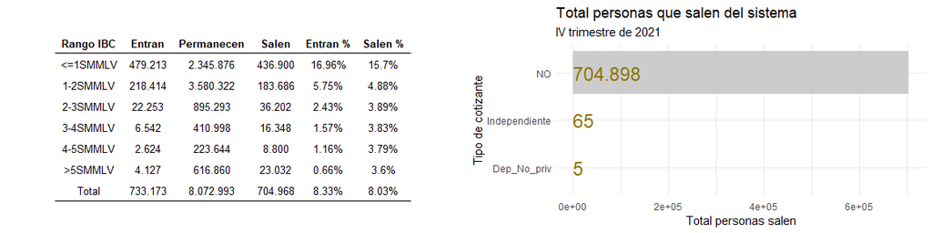

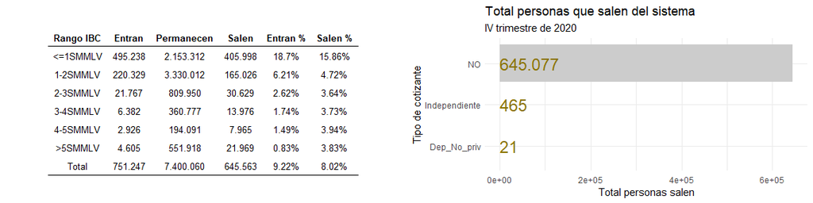

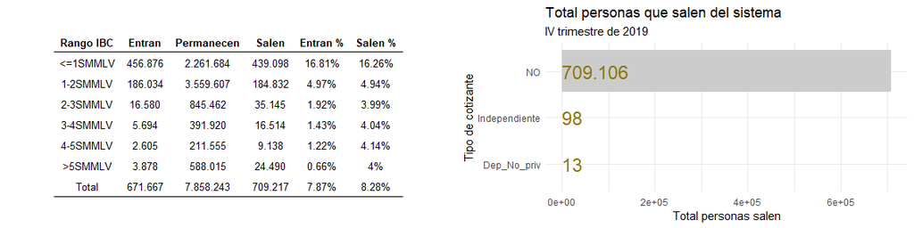

### Sección económica

Se observó un decrecimiento en el número de cotizantes en relación con noviembre, en donde las secciones económicas de Educación y Construcción registraron una reducción en su número de cotizantes. Caso contrario se registra en las empresas de información y comunicaciones, y alojamiento y servicios de comida, en las que se observó un crecimiento destacado.

Distribución de los cotizantes dependientes de sec. privado por Sección Economica

|  | Actividad(sección CIIU Rev.4) | Dic-20 | Nov-21 | Dic-21 | Distribución (%) | var Dic - Nov 21 | Contri. | var Dic 21-20 | Contri. |
| --- | --- | --- | --- | --- | --- | --- | --- | --- | --- |
| 15 | Actividades de servicios administrativos y de apoyo | 1.764,4 | 1.590,0 | 1.764,6 | 20.2% | 0.01% | 0% | 10.98% | 2.15% |
| 8 | Comercio al por mayor y al por menor | 1.292,0 | 1.181,8 | 1.288,6 | 14.75% | -0.26% | -0.04% | 9.04% | 1.32% |
| 4 | Industrias manufactureras | 1.044,2 | 977,4 | 1.035,3 | 11.85% | -0.85% | -0.1% | 5.93% | 0.71% |
| 11 | Información y comunicaciones | 285,9 | 237,5 | 284,9 | 3.26% | -0.36% | -0.01% | 19.95% | 0.58% |
| 10 | Alojamiento y servicios de comida | 242,0 | 202,5 | 242,5 | 2.78% | 0.18% | 0% | 19.76% | 0.49% |
| 18 | Actividades de atención de la salud humana | 421,9 | 383,9 | 419,9 | 4.81% | -0.46% | -0.02% | 9.4% | 0.44% |
| 9 | Transporte y almacenamiento | 525,6 | 484,3 | 519,7 | 5.95% | -1.12% | -0.07% | 7.31% | 0.44% |
| 14 | Actividades profesionales, científicas y técnicas | 572,1 | 535,7 | 560,9 | 6.42% | -1.95% | -0.13% | 4.71% | 0.31% |
| 7 | Construcción | 830,7 | 758,8 | 782,4 | 8.95% | -5.81% | -0.54% | 3.11% | 0.29% |
| 2 | Agricultura, ganadería, caza, silvicultura y pesca | 360,0 | 338,6 | 356,4 | 4.08% | -1.01% | -0.04% | 5.27% | 0.22% |
| 1 | Otras | 168,1 | 149,4 | 163,5 | 1.87% | -2.74% | -0.05% | 9.41% | 0.17% |
| 3 | Explotación de minas y canteras | 106,0 | 94,5 | 103,8 | 1.19% | -2.1% | -0.02% | 9.83% | 0.11% |
| 19 | Actividades artísticas, de entretenimiento y recreación | 82,8 | 75,1 | 82,4 | 0.94% | -0.44% | 0% | 9.82% | 0.09% |
| 20 | Otras actividades de servicios | 329,2 | 313,2 | 320,3 | 3.67% | -2.7% | -0.1% | 2.26% | 0.09% |
| 13 | Actividades inmobiliarias | 99,4 | 93,7 | 98,7 | 1.13% | -0.72% | -0.01% | 5.33% | 0.06% |
| 12 | Actividades financieras y de seguros | 258,5 | 252,6 | 257,5 | 2.95% | -0.37% | -0.01% | 1.96% | 0.06% |
| 17 | Educación | 303,5 | 253,1 | 257,1 | 2.94% | -15.28% | -0.52% | 1.59% | 0.05% |
| 6 | Distribución de agua | 53,4 | 50,7 | 53,5 | 0.61% | 0.08% | 0% | 5.46% | 0.03% |
| 5 | Suministro de electricidad, gas, vapor y aire | 16,8 | 15,8 | 16,9 | 0.19% | 0.84% | 0% | 7.34% | 0.01% |
| 21 | Actividades de los hogares individuales | 18,1 | 17,5 | 17,6 | 0.2% | -2.41% | 0% | 1.04% | 0% |
| 23 | Actividades de organizaciones y ent. extraterritoriales | 3,3 | 3,3 | 3,3 | 0.04% | -0.57% | 0% | 1.26% | 0% |
| 16 | Administración pública y defensa | 112,0 | 109,1 | 107,7 | 1.23% | -3.89% | -0.05% | -1.27% | -0.02% |
| 22 | Total | 8.889,9 | 8.118,2 | 8.737,6 | 100% | -1.71% | -1.71% | 7.63% | 7.63% |

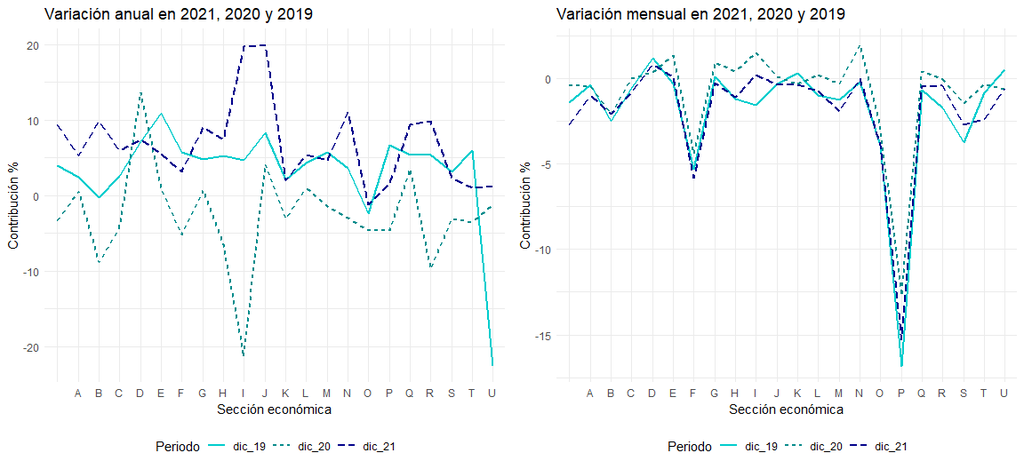

### Aspectos demográficos

En diciembre de 2021 se identificaron 5.026.135 hombres y 3.656.982 y mujeres, es decir 72.76 mujeres por cada 100 hombres, promedio superior al observado en 2020 que fue de 70.78.

Resumen por sexo de los cotizantes del sector privado en 2021

| Año | Mes | Total Hombres | Total Mujeres | Razon sexo F/H | Hombres (%) | Mujeres (%) | Total jovenes | Jovenes (%) |
| --- | --- | --- | --- | --- | --- | --- | --- | --- |
| 2019 | Sep | 4.931.753 | 3.494.639 | 70.86 | 58.53% | 41.47% | 2.139.202 | 25.39% |
| 2019 | Oct | 4.970.392 | 3.520.688 | 70.83 | 58.54% | 41.46% | 2.189.323 | 25.78% |
| 2019 | Nov | 4.983.285 | 3.536.611 | 70.97 | 58.49% | 41.51% | 2.231.690 | 26.19% |
| 2019 | Dic | 4.892.048 | 3.475.770 | 71.05 | 58.46% | 41.54% | 2.229.651 | 26.65% |
| 2020 | Sep | 4.672.663 | 3.255.299 | 69.67 | 58.94% | 41.06% | 1.876.756 | 23.67% |
| 2020 | Oct | 4.739.429 | 3.308.773 | 69.81 | 58.89% | 41.11% | 1.946.740 | 24.19% |
| 2020 | Nov | 4.786.655 | 3.361.639 | 70.23 | 58.74% | 41.26% | 2.017.173 | 24.76% |
| 2020 | Dic | 4.748.257 | 3.360.612 | 70.78 | 58.56% | 41.44% | 2.043.859 | 25.21% |
| 2021 | Sep | 5.065.737 | 3.631.338 | 71.68 | 58.25% | 41.75% | 2.331.329 | 26.81% |
| 2021 | Oct | 5.098.640 | 3.667.813 | 71.94 | 58.16% | 41.84% | 2.386.677 | 27.23% |
| 2021 | Nov | 5.134.547 | 3.707.443 | 72.21 | 58.07% | 41.93% | 2.451.868 | 27.73% |
| 2021 | Dic | 5.026.135 | 3.656.982 | 72.76 | 57.88% | 42.12% | 2.437.065 | 28.07% |

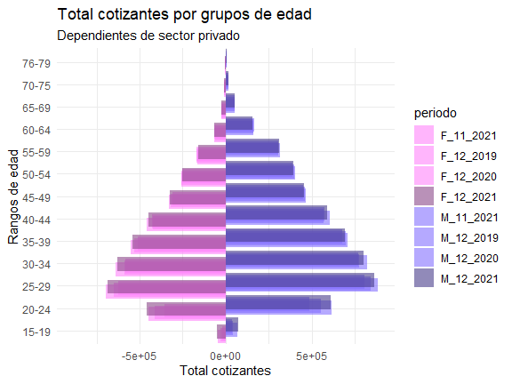

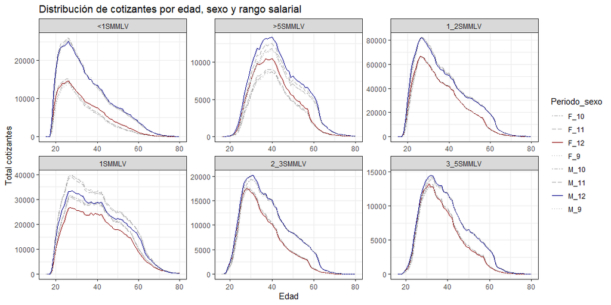

### Aspectos geográficos

La disminución del número de cotizantes del sector privado fue sistemática en los diversos departamentos del país al igual que los incrementos en noviembre de 2021. Zonas como la Costa Atlántica y la Costa Pacífica presentaron un decrecimiento menos fuerte en diciembre.

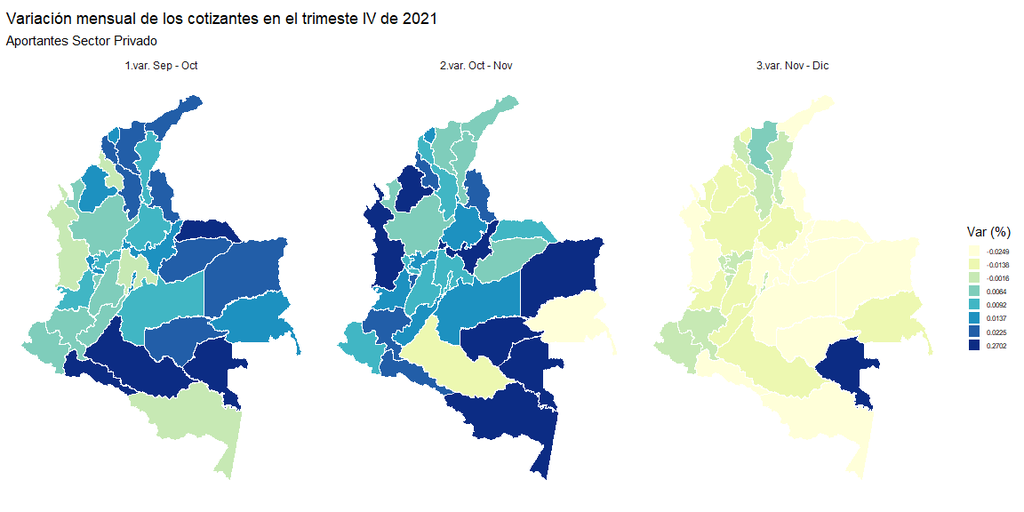

## Independientes

En diciembre 2021 cotizaron 2.203.155 de manera independiente al sistema, es decir, una variación mensual de -3.54% cifra inferior a lo registrado en 2020 cuando fue del -1.37% y en la misma tendencia a lo obtenido en 2019 que fue del -3.47%.

Matriz resumen de la dinamica pareada entre Diciembre y Noviembre de 2021

| Mes | Entran | Permanecen | Salen | Salen con Retiro | Salen sin Retiro | Entran (%) | Salen (%) |
| --- | --- | --- | --- | --- | --- | --- | --- |
| <=1SMMLV | 95.053 | 1.404.834 | 160.948 | 80.674 | 80.274 | 6.34% | 10.28% |
| 1-2_SMMLV | 16.079 | 408.786 | 40.791 | 14.660 | 26.131 | 3.78% | 9.07% |
| 2-3_SMMLV | 4.128 | 116.031 | 8.169 | 2.543 | 5.626 | 3.44% | 6.58% |
| 3-4_SMMLV | 1.939 | 50.765 | 2.940 | 952 | 1.988 | 3.68% | 5.47% |
| 4-5_SMMLV | 925 | 23.425 | 1.305 | 446 | 859 | 3.8% | 5.28% |
| >5_SMMLV | 3.739 | 55.962 | 3.062 | 1.327 | 1.735 | 6.26% | 5.19% |
| Total | 121.863 | 2.059.803 | 217.215 | 100.602 | 116.613 | 5.59% | 9.54% |

Matriz resumen de la dinamica pareada entre Noviembre y Octubre de 2021

| Mes | Entran | Permanecen | Salen | Salen con Retiro | Salen sin Retiro | Entran (%) | Salen (%) |
| --- | --- | --- | --- | --- | --- | --- | --- |
| <=1SMMLV | 108.629 | 1.418.692 | 116.916 | 61.548 | 55.368 | 7.11% | 7.61% |
| 1-2_SMMLV | 19.530 | 455.927 | 18.838 | 7.436 | 11.402 | 4.11% | 3.97% |
| 2-3_SMMLV | 4.350 | 125.808 | 3.902 | 1.517 | 2.385 | 3.34% | 3.01% |
| 3-4_SMMLV | 1.795 | 53.439 | 1.512 | 543 | 969 | 3.25% | 2.75% |
| 4-5_SMMLV | 808 | 24.254 | 738 | 317 | 421 | 3.22% | 2.95% |
| >5_SMMLV | 2.243 | 54.137 | 1.765 | 859 | 906 | 3.98% | 3.16% |
| Total | 137.355 | 2.132.257 | 143.671 | 72.220 | 71.451 | 6.05% | 6.31% |

- La diferencia de salidas en 2021 con salidas en 2020 es de 70.543 superior a la diferencia de salidas entre 2020 y 2019, que fueron del -38.472. El número de salidas en diciembre 2019 y 2020 fueron de 185.144 y 146.672 respectivamente.
- La diferencia de entradas en 2021 con entradas en 2020 es de 4.993 inferior a la diferencia de entradas entre 2020 y 2019, que llegó a 10.394. El número de entradas en diciembre 2019 y 2020 fueron de 106.476 y 116.870 respectivamente.

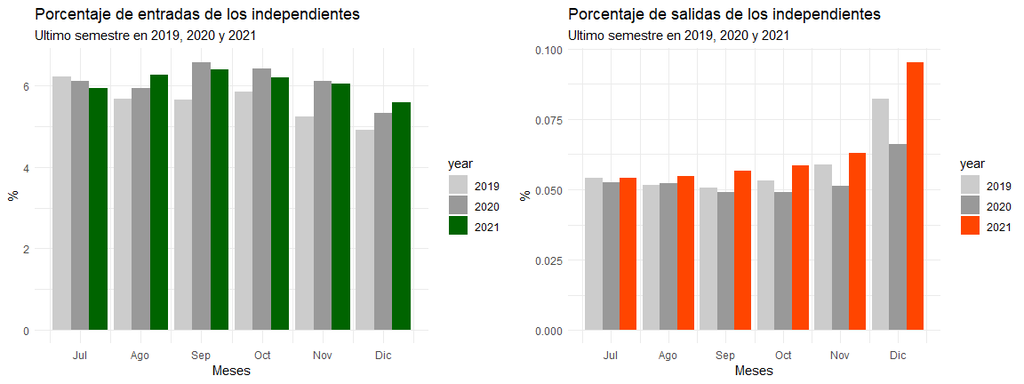

Matriz resumen de la dinamica pareada entre Diciembre y Noviembre de 2020

| Mes | Entran | Permanecen | Salen | Salen con Retiro | Salen sin Retiro | Entran (%) | Salen (%) |
| --- | --- | --- | --- | --- | --- | --- | --- |
| <=1SMMLV | 89.933 | 1.440.018 | 110.848 | 70.291 | 40.557 | 5.88% | 7.15% |
| 1-2_SMMLV | 15.637 | 399.786 | 26.530 | 13.081 | 13.449 | 3.76% | 6.22% |
| 2-3_SMMLV | 4.343 | 116.019 | 5.155 | 2.242 | 2.913 | 3.61% | 4.25% |
| 3-4_SMMLV | 1.603 | 46.237 | 1.584 | 721 | 863 | 3.35% | 3.31% |
| 4-5_SMMLV | 1.048 | 21.739 | 763 | 359 | 404 | 4.6% | 3.39% |
| >5_SMMLV | 4.306 | 51.975 | 1.792 | 1.098 | 694 | 7.65% | 3.33% |
| Total | 116.870 | 2.075.774 | 146.672 | 87.792 | 58.880 | 5.33% | 6.6% |

Matriz resumen de la dinamica pareada entre Diciembre y Noviembre de 2019

| Mes | Entran | Permanecen | Salen | Salen con Retiro | Salen sin Retiro | Entran (%) | Salen (%) |
| --- | --- | --- | --- | --- | --- | --- | --- |
| <=1SMMLV | 82.566 | 1.449.509 | 139.231 | 90.701 | 48.530 | 5.39% | 8.76% |
| 1-2_SMMLV | 14.001 | 375.120 | 34.644 | 18.373 | 16.271 | 3.6% | 8.45% |
| 2-3_SMMLV | 3.614 | 111.313 | 6.506 | 3.203 | 3.303 | 3.14% | 5.52% |
| 3-4_SMMLV | 1.432 | 48.590 | 1.939 | 935 | 1.004 | 2.86% | 3.84% |
| 4-5_SMMLV | 985 | 23.515 | 861 | 456 | 405 | 4.02% | 3.53% |
| >5_SMMLV | 3.878 | 53.114 | 1.963 | 1.129 | 834 | 6.8% | 3.56% |
| Total | 106.476 | 2.061.161 | 185.144 | 114.797 | 70.347 | 4.91% | 8.24% |

**Relaciones laborales que permanecieron**

El porcentaje promedio de las relaciones laborales que disminuyeron, aumentaron o permanecieron su rango salarial fue de 14.98%,5.42% y 83%, promedios similares a lo observado en 2020 que llegaron al 14.93%,5.72% y 82.79%, así como a las de 2019 que fueron de 15.88%,5.23% y 82.41%.

Matriz de trancisión entre Noviembre y Diciembre de 2021

| Rango pre | <=1SMMLV | 1-2SMMLV | 2-3SMMLV | 3-4SMMLV | 4-5SMMLV | >5SMMLV | Disminuyen % | Incrementan % |
| --- | --- | --- | --- | --- | --- | --- | --- | --- |
| <=1SMMLV | 97.76% | 1.72% | 0.26% | 0.09% | 0.04% | 0.12% | 0% | 2.24% |
| 1-2SMMLV | 12.6% | 84.41% | 1.9% | 0.5% | 0.19% | 0.39% | 12.6% | 2.99% |
| 2-3SMMLV | 4.57% | 9.95% | 79.98% | 3.16% | 0.92% | 1.42% | 14.52% | 5.51% |
| 3-4SMMLV | 2.98% | 5.96% | 7.46% | 76.72% | 3.33% | 3.55% | 16.4% | 6.89% |
| 4-5SMMLV | 2.54% | 3.15% | 5.63% | 7.34% | 71.86% | 9.47% | 18.67% | 9.47% |
| >5SMMLV | 2.03% | 1.95% | 2.18% | 2.81% | 3.74% | 87.29% | 12.71% | 0% |

Matriz de trancisión entre Noviembre y Diciembre de 2020

| Rango pre | <=1SMMLV | 1-2SMMLV | 2-3SMMLV | 3-4SMMLV | 4-5SMMLV | >5SMMLV | Disminuyen % | Incrementan % |
| --- | --- | --- | --- | --- | --- | --- | --- | --- |
| <=1SMMLV | 97.61% | 1.86% | 0.27% | 0.09% | 0.04% | 0.13% | 0% | 2.39% |
| 1-2SMMLV | 11.91% | 84.9% | 2.04% | 0.51% | 0.21% | 0.44% | 11.91% | 3.2% |
| 2-3SMMLV | 5.14% | 9.15% | 80.25% | 3.07% | 0.99% | 1.41% | 14.29% | 5.46% |
| 3-4SMMLV | 3.17% | 5.43% | 8.13% | 75.79% | 3.55% | 3.92% | 16.73% | 7.47% |
| 4-5SMMLV | 2.76% | 3.05% | 5.5% | 7.56% | 71.08% | 10.06% | 18.86% | 10.06% |
| >5SMMLV | 2.21% | 2.07% | 2.1% | 2.73% | 3.74% | 87.14% | 12.86% | 0% |

Matriz de trancisión entre Noviembre y Diciembre de 2019

| Rango pre | <=1SMMLV | 1-2SMMLV | 2-3SMMLV | 3-4SMMLV | 4-5SMMLV | >5SMMLV | Disminuyen % | Incrementan % |
| --- | --- | --- | --- | --- | --- | --- | --- | --- |
| <=1SMMLV | 98.18% | 1.36% | 0.21% | 0.08% | 0.04% | 0.13% | 0% | 1.82% |
| 1-2SMMLV | 14.27% | 82.73% | 1.87% | 0.49% | 0.2% | 0.44% | 14.27% | 3% |
| 2-3SMMLV | 6.89% | 9.99% | 78.05% | 2.9% | 0.88% | 1.3% | 16.88% | 5.08% |
| 3-4SMMLV | 3.79% | 5.39% | 7.28% | 76.56% | 3.52% | 3.46% | 16.47% | 6.97% |
| 4-5SMMLV | 2.94% | 3.36% | 4.79% | 7.46% | 72.15% | 9.29% | 18.56% | 9.29% |
| >5SMMLV | 2.53% | 2.19% | 2.02% | 2.71% | 3.75% | 86.8% | 13.2% | 0% |

### Sección económica

El total de cotizantes independientes disminuyó en relación con noviembre, exactamente en el sector de Educación.

Distribución de los cotizantes dependientes de sec. privado por Sección Economica

|  | Actividad(sección CIIU Rev.4) | Dic-20 | Nov-21 | Dic-21 | Distribución (%) | var Dic - Nov 21 | Contri. | var Dic 21-20 | Contri. |
| --- | --- | --- | --- | --- | --- | --- | --- | --- | --- |
| 15 | Actividades de servicios administrativos y de apoyo | 325,8 | 295,1 | 310,9 | 14.11% | -4.58% | -0.65% | 5.33% | 0.72% |
| 17 | Educación | 147,0 | 128,6 | 137,1 | 6.22% | -6.71% | -0.43% | 6.62% | 0.39% |
| 20 | Otras actividades de servicios | 179,4 | 169,2 | 175,9 | 7.98% | -1.96% | -0.15% | 3.95% | 0.31% |
| 9 | Transporte y almacenamiento | 106,5 | 99,0 | 104,2 | 4.73% | -2.1% | -0.1% | 5.24% | 0.24% |
| 19 | Actividades artísticas, de entretenimiento y recreación | 45,1 | 39,9 | 42,5 | 1.93% | -5.84% | -0.12% | 6.33% | 0.12% |
| 1 | Otras | 34,0 | 30,2 | 32,1 | 1.46% | -5.55% | -0.08% | 6.33% | 0.09% |
| 18 | Actividades de atención de la salud humana | 192,2 | 183,6 | 185,3 | 8.41% | -3.59% | -0.3% | 0.95% | 0.08% |
| 8 | Comercio al por mayor y al por menor | 216,8 | 211,2 | 212,1 | 9.63% | -2.15% | -0.2% | 0.44% | 0.04% |
| 7 | Construcción | 61,6 | 58,5 | 59,3 | 2.69% | -3.77% | -0.1% | 1.25% | 0.03% |
| 6 | Distribución de agua | 4,6 | 4,0 | 4,5 | 0.2% | -3.69% | -0.01% | 12.51% | 0.02% |
| 3 | Explotación de minas y canteras | 4,6 | 4,2 | 4,4 | 0.2% | -5.31% | -0.01% | 4.56% | 0.01% |
| 5 | Suministro de electricidad, gas, vapor y aire | 1,0 | 0,9 | 0,9 | 0.04% | -7.17% | 0% | 4.44% | 0% |
| 23 | Actividades de organizaciones y ent. extraterritoriales | 0,4 | 0,4 | 0,4 | 0.02% | -7.14% | 0% | -12.16% | 0% |
| 21 | Actividades de los hogares individuales | 13,9 | 13,7 | 13,5 | 0.61% | -2.33% | -0.01% | -1% | -0.01% |
| 12 | Actividades financieras y de seguros | 15,9 | 15,5 | 15,2 | 0.69% | -4.26% | -0.03% | -1.79% | -0.01% |
| 10 | Alojamiento y servicios de comida | 43,2 | 42,3 | 41,4 | 1.88% | -4.24% | -0.08% | -2.15% | -0.04% |
| 2 | Agricultura, ganadería, caza, silvicultura y pesca | 60,0 | 59,6 | 58,2 | 2.64% | -3.11% | -0.08% | -2.46% | -0.07% |
| 13 | Actividades inmobiliarias | 51,6 | 52,8 | 50,8 | 2.31% | -1.39% | -0.03% | -3.64% | -0.09% |
| 4 | Industrias manufactureras | 70,4 | 70,4 | 68,3 | 3.1% | -2.98% | -0.09% | -2.94% | -0.09% |
| 14 | Actividades profesionales, científicas y técnicas | 564,9 | 548,8 | 546,6 | 24.81% | -3.24% | -0.8% | -0.4% | -0.1% |
| 11 | Información y comunicaciones | 46,2 | 53,0 | 44,5 | 2.02% | -3.67% | -0.07% | -15.95% | -0.39% |
| 16 | Administración pública y defensa | 99,0 | 105,2 | 95,0 | 4.31% | -4.02% | -0.17% | -9.7% | -0.47% |
| 22 | Total | 2.284,1 | 2.186,1 | 2.203,2 | 100% | -3.54% | -3.54% | 0.78% | 0.78% |

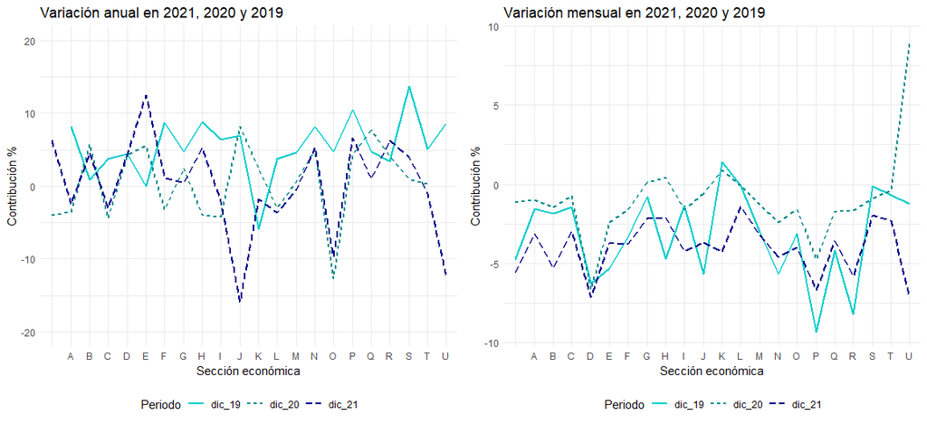

### Aspectos Demográficos

Resumen por sexo de los cotizantes del sector privado en 2021

| Año | Mes | Total Hombres | Total Mujeres | Razon sexo F/H | Hombres (%) | Mujeres (%) | Total jovenes | Jovenes (%) |
| --- | --- | --- | --- | --- | --- | --- | --- | --- |
| 2019 | Sep | 1.124.245 | 1.118.035 | 99.45 | 50.14% | 49.86% | 244.500 | 10.9% |
| 2019 | Oct | 1.135.161 | 1.121.653 | 98.81 | 50.3% | 49.7% | 251.836 | 11.16% |
| 2019 | Nov | 1.127.240 | 1.115.838 | 98.99 | 50.25% | 49.75% | 248.164 | 11.06% |
| 2019 | Dic | 1.090.692 | 1.074.833 | 98.55 | 50.37% | 49.63% | 231.016 | 10.67% |
| 2020 | Sep | 1.075.752 | 1.079.263 | 100.33 | 49.92% | 50.08% | 223.856 | 10.39% |
| 2020 | Oct | 1.095.808 | 1.094.340 | 99.87 | 50.03% | 49.97% | 236.324 | 10.79% |
| 2020 | Nov | 1.105.050 | 1.108.627 | 100.32 | 49.92% | 50.08% | 245.397 | 11.09% |
| 2020 | Dic | 1.090.033 | 1.092.445 | 100.22 | 49.94% | 50.06% | 240.568 | 11.02% |
| 2021 | Sep | 1.126.860 | 1.137.859 | 100.98 | 49.76% | 50.24% | 278.025 | 12.28% |
| 2021 | Oct | 1.130.019 | 1.145.913 | 101.41 | 49.65% | 50.35% | 286.080 | 12.57% |
| 2021 | Nov | 1.132.079 | 1.145.912 | 101.22 | 49.7% | 50.3% | 292.030 | 12.82% |
| 2021 | Dic | 1.091.336 | 1.105.285 | 101.28 | 49.68% | 50.32% | 277.665 | 12.64% |

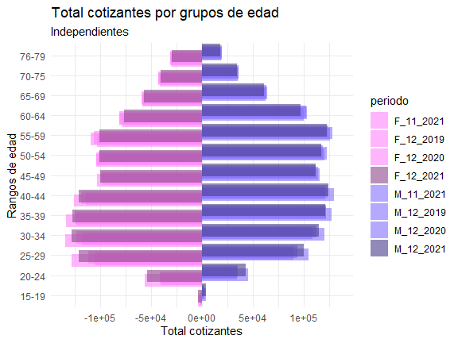

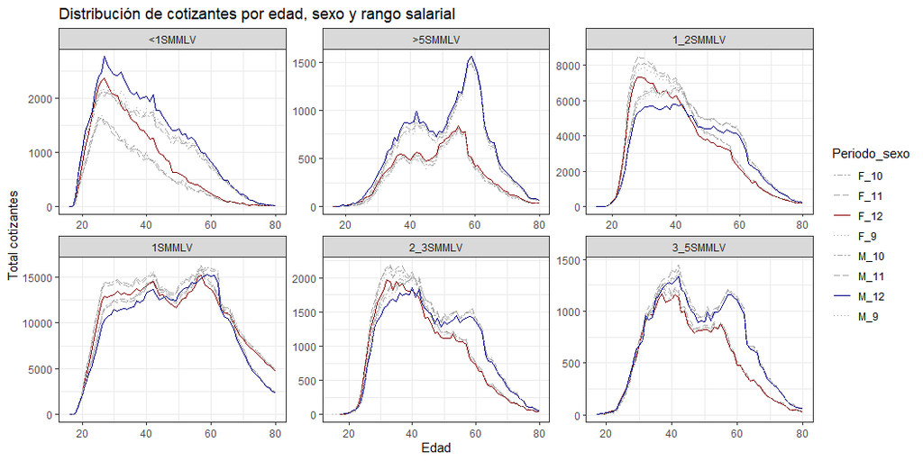

### Aspectos geográficos

La disminución del número de cotizantes independientes fue sistemática en diferentes zonas del al igual que los incrementos en noviembre de 2021. Departamentos como Valle del Cauca o Antioquia no mostraron cambios sustanciales entre noviembre y diciembre.

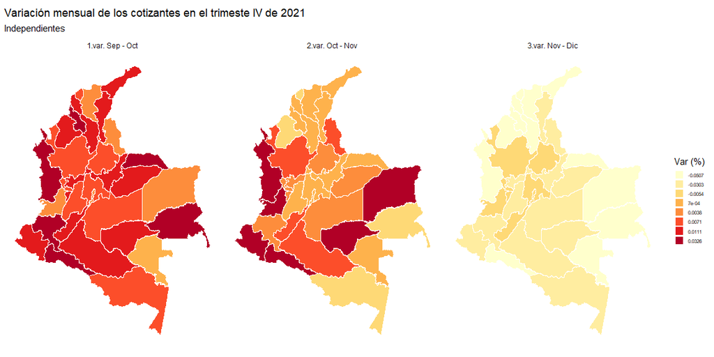

# Monto de cotización

El aporte total en el último trimestre 2021 fue de $18,9 billones, es decir un crecimiento del 6.69% en relación con 2020 y del 6.7% en 2019.

Matriz resumen del monto de cotizacion realizado en diciembre 2019, 2020 y 2021 asi como las variaciones mensuales y anuales por rango y tipo de cotizantes

| Tipo | Rango IBC | Monto en muillones 2019 | Monto en muillones 2020 | Monto en muillones 2021 | Variación mensual 2018 | Variación mensual 2019 | Variación mensual 2020 | Variación mensual 2021 | Variacón anual 2019 | Variacón anual 2020 | Variacón anual 2021 |
| --- | --- | --- | --- | --- | --- | --- | --- | --- | --- | --- | --- |
| Dependientes | <1SMMLV | $108.704 | $94.278 | $100.439 | 40.74% | 45.03% | 24.7% | 14.61% | 12.1% | -13.27% | 6.54% |
| Dependientes | 1SMMLV | $445.821 | $452.993 | $461.918 | -16.03% | -15.89% | -11.73% | -13.8% | 4.77% | 1.61% | 1.97% |
| Dependientes | 1_2SMMLV | $1.155.146 | $1.175.724 | $1.235.116 | -5.11% | -5.17% | -2.41% | -2.52% | 4.47% | 1.78% | 5.05% |
| Dependientes | 2_5SMMLV | $1.268.724 | $1.294.650 | $1.392.344 | -6.38% | -6.32% | -4.75% | -5.34% | 4.33% | 2.04% | 7.55% |
| Dependientes | >5SMMLV | $2.394.155 | $2.404.857 | $2.552.895 | 20.72% | 20.35% | 20.2% | 17.98% | 3.65% | 0.45% | 6.16% |
| Dependientes | Total_IBC | $5.372.550 | $5.422.501 | $5.742.713 | 4.06% | 3.98% | 5.22% | 3.94% | 4.24% | 0.93% | 5.91% |
| Independientes | <1SMMLV | $13.111 | $10.703 | $12.065 | 47.61% | 117.64% | 43.81% | 55.89% | 95.56% | -18.36% | 12.72% |
| Independientes | 1SMMLV | $269.833 | $287.960 | $281.263 | -4.01% | -4.94% | -1.87% | -4.43% | 7.19% | 6.72% | -2.33% |
| Independientes | 1_2SMMLV | $128.208 | $140.391 | $145.706 | -11.78% | -15.12% | -9.76% | -12.51% | 4.49% | 9.5% | 3.79% |
| Independientes | 2_5SMMLV | $128.636 | $135.215 | $139.248 | -7.15% | -7.74% | -4.04% | -6.42% | 10.49% | 5.11% | 2.98% |
| Independientes | >5SMMLV | $138.233 | $139.599 | $148.358 | 17.48% | 14.03% | 16.2% | 9.7% | 7.86% | 0.99% | 6.27% |
| Independientes | Total_IBC | $678.021 | $713.868 | $726.640 | -2.28% | -3.36% | -0.51% | -3.45% | 8.36% | 5.29% | 1.79% |
| Total | Total | $6.050.571 | $6.136.369 | $6.469.353 | 3.33% | 3.1% | 4.52% | 3.05% | 4.68% | 1.42% | 5.43% |

Note:  
Se toman en cuenta montos deflactados a partir del valor del IPC con referencia diciembre 2021

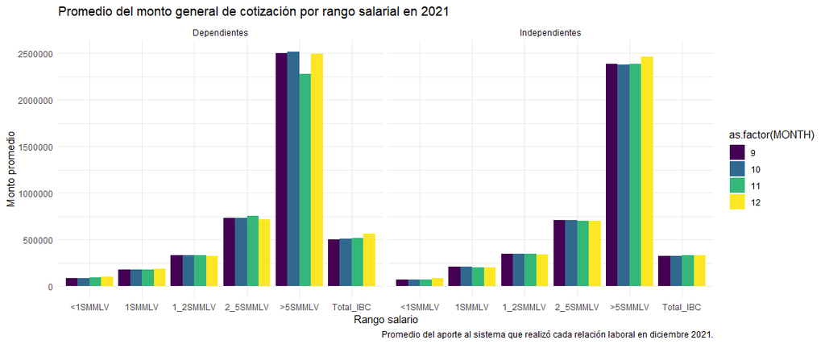

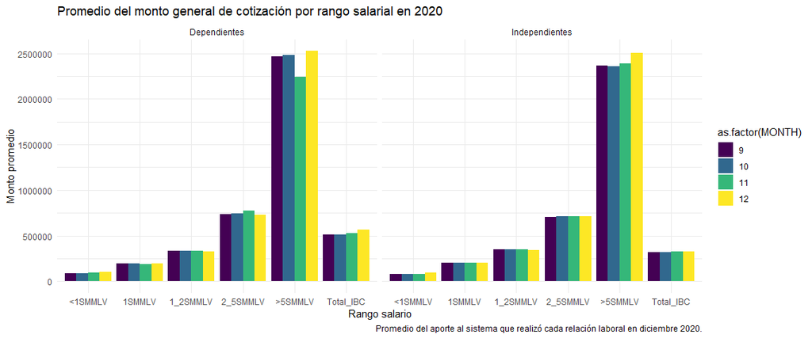

## Resumen por subsistema

Monto total por subsistema en millones para el ultimo semestre de 2021 según el tipo de cotizantes

|  | Tipo | Mes | Pago en salud | Pago en pensión | Pago en ARL | Pago en CCF | Pago en SENA | Pago en ICBF | Pago total |
| --- | --- | --- | --- | --- | --- | --- | --- | --- | --- |
| 552 | Dependientes | Jul | $1.170.829 | $2.669.145 | $362.691 | $730.035 | $98.376 | $216.470 | $5.247.545 |
| 565 | Dependientes | Ago | $1.184.002 | $2.702.994 | $372.691 | $718.557 | $94.920 | $201.422 | $5.274.586 |
| 578 | Dependientes | Sep | $1.193.401 | $2.711.588 | $374.684 | $721.661 | $95.956 | $204.420 | $5.301.710 |
| 591 | Dependientes | Oct | $1.206.459 | $2.741.980 | $377.960 | $729.505 | $97.510 | $206.407 | $5.359.820 |
| 604 | Dependientes | Nov | $1.233.391 | $2.801.320 | $388.088 | $766.296 | $105.268 | $230.897 | $5.525.259 |
| 617 | Dependientes | Dic | $1.327.717 | $2.879.048 | $378.670 | $785.325 | $119.583 | $252.369 | $5.742.713 |
| 598 | Independientes | Jul | $345.195 | $342.038 | $28.331 | $3.701 | $30 | $53 | $719.348 |
| 571 | Independientes | Ago | $348.533 | $346.664 | $28.923 | $3.806 | $32 | $90 | $728.048 |
| 584 | Independientes | Sep | $351.795 | $351.072 | $29.505 | $3.868 | $34 | $99 | $736.374 |
| 597 | Independientes | Oct | $355.650 | $356.017 | $30.081 | $3.911 | $35 | $97 | $745.791 |
| 610 | Independientes | Nov | $358.234 | $359.813 | $30.527 | $3.927 | $40 | $96 | $752.636 |
| 623 | Independientes | Dic | $347.494 | $346.250 | $28.912 | $3.843 | $35 | $106 | $726.640 |
| 519 | Total | Jul | $1.516.024 | $3.011.183 | $391.021 | $733.736 | $98.406 | $216.523 | $5.966.893 |
| 516 | Total | Ago | $1.532.535 | $3.049.658 | $401.614 | $722.363 | $94.952 | $201.512 | $6.002.634 |
| 526 | Total | Sep | $1.545.196 | $3.062.660 | $404.189 | $725.529 | $95.990 | $204.519 | $6.038.084 |
| 525 | Total | Oct | $1.562.110 | $3.097.998 | $408.040 | $733.415 | $97.545 | $206.504 | $6.105.611 |
| 482 | Total | Nov | $1.591.625 | $3.161.133 | $418.615 | $770.223 | $105.307 | $230.993 | $6.277.896 |
| 495 | Total | Dic | $1.675.211 | $3.225.298 | $407.582 | $789.169 | $119.618 | $252.475 | $6.469.353 |

Note:  
Se toman en cuenta montos deflactados a partir del valor del IPC con referencia diciembre 2021

# Complementos

## Evolución de las personas en el régimen contributivo frente al subsidiado

En diciembre 2021 hay cerca de 1.01 personas en el régimen subsidiado por cada 100 que hay en el régimen contributivo, tasa inversa a la observada en 2019 y 2020 donde hay cerca de 1.009 y 1.038 personas subsidiadas por cada 100 subsidiada.

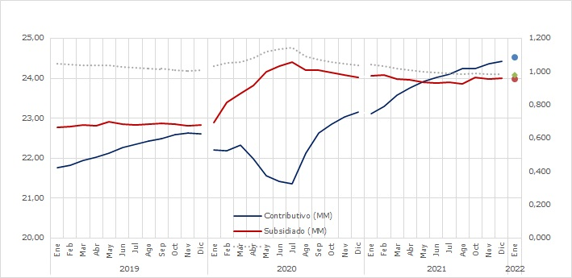

Total personas afiliadas al regimen subsidiado y contributivo desde enero 2019 a enero 2022, tomado del reporte publicado por la Administradora de los Recursos del Sistema General de Seguridad Social en Salud (ADRES).

## Contraste de frente a las proyecciones de población

Las proyecciones de población en Colombia entre 12 y 65 años son de 37.092.913 personas para 2021, es decir 322.1 cotizantes por cada mil personas, de las cuales 283.39 son mujeres y 362.79 son hombres

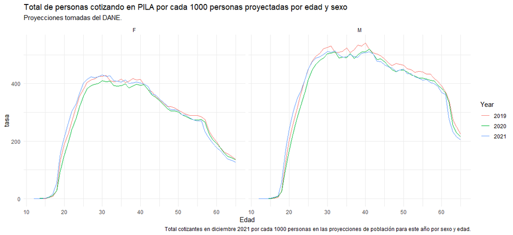